# Code used for the overview

Moraes, L. S. C. et al.

2025-01-21

Here are all the code we used to modify the dataset, build graphs and perform the analysis.

If you wish, it is possible run this code with the dataset in the Suplemmentary Material.

The packages used:

```r
packages <- c("openxlsx", "tidyverse", "patchwork", "egg", "scales", "ggsci", "bipartite", "qgraph", "networkD3", "igraph", "paletteer", "sf", "ggforce")

install_and_load_packages <- function(packages) {
  for(package in packages) {
    if(!require(package, character.only = TRUE)) {
      install.packages(package)
      library(package, character.only = TRUE)
    }
  }
}

install_and_load_packages(packages)
```

# Data import and organization

Loading the data:

```r
elect <- read.xlsx("Elected articles.xlsx", startRow = 2)
```

Removing collected variables that:

1 - Are unimportant for this work (colunm $2$ = times cited; $4$ = Web of Science category; $5$ = Research field; $6$ = Type of publication - are all scientific articles; $7$ = Authors; $55$ = Observations);

2 - Are probably inaccurate ($42$ = Host specialization; $46$ = Host size, in centimeters).

```r
all_data <- elect[, -c(2, 4:7, 42, 46, 55)]
```

Simplifying variable names and selecting them:

```r
data <- all_data  |>
  mutate_if(is.character, as.factor)  |>
  dplyr::rename(
    source = Source.Title,
    pphy = Parasite.phylum,
    pclass = Parasite.class,
    porder = Parasite.order,
    pfamily = Parasite.family,
    pgen = Parasite.genus,
    psp = Parasite.species,
    porigin = Parasite.origin,
    repro = Reproduction,
    pstyle =  Parasite.specialization,
    kind = Euc.proc.or.virus,
    methodology = Identification.methodology,
    host.type = Life.stage,
    site = Infection.site,
    hphy = Invaded.host.phylum,
    hclass = Invaded.host.class,
    horder = Invaded.host.order,
    hfamily = Invaded.host.family,
    hgenus = Invaded.host.genus,
    hsp = Invaded.host.species,
    invaded.host.origin = Invaded.host.indigenous.to,
    original.host.continent = Original.host.Indigenous.to.Continent,
    host.feeding = Invaded.host.Feeding.behaviour,
    status = IUCN.Red.List.Status,
    htroph = Trophic.level,
    shchooling = Shoaling.or.Schooling,
    ambiguous = Ambiguous.native.range,
    ambstudy = Study.environment,
    lab = Experiment,
    factor.ind = Factor.inducing.invasion,
    continent = Invaded.continent,
    country = Invaded.country,
    meltdown = Invasion.meltdown
  )  |>
  dplyr::select(
    ID, Year, source, Native.host, pphy, pclass, porder, pfamily, pgen, psp, porigin, Life.cycle, repro, pstyle, N.host.orders, N.host.families, Ecto.or.Endo, methodology, host.type, site, hphy, hclass, horder, hfamily, hgenus, hsp, invaded.host.origin, original.host.continent, host.feeding, status, htroph, Migrant, shchooling, ambiguous, ambstudy, lab, factor.ind, Spillmode, continent, country, meltdown, Invaded.area
  )
```

Simplifying categorical values (levels) of the variable *factor.ind*, which stands for “factor inducing invasions”:

```r
data$factor.ind <- gsub("(Eel.*|eel.*|fish farm.*)", "Pisciculture", data$factor.ind)
data$factor.ind <- gsub("fisherman", "Fisherman", data$factor.ind)
data$factor.ind <- gsub("(Not known|Not mentioned|Unknow)", "Not mentioned or unknown", data$factor.ind)
data$factor.ind <- gsub(".*rism", "Aquarism", data$factor.ind)
data$factor.ind <- gsub(".*ol", "Biological control", data$factor.ind)
```

Changing the $?$ symbol for “Unkown” in other variables:

```r
data$repro <- gsub("\\?", "Unknown", data$repro)
data$host.feeding <- gsub("\\?", "Unknown", data$host.feeding)
data$htroph <- gsub("\\?", "Unknown", data$htroph)
data$Migrant <- gsub("\\?", "Unknown", data$Migrant)
data$shchooling <- gsub("\\?", "Unknown", data$shchooling)
```

From now on, we will use the *data* dataset.

# Ciensciometry

## Number of:

**1** - observations in each category of each variable (those were used to create the *Suplemmentary material 2*):

```r
lapply(data[c(2, 5, 12:14, 17:19, 23, 29:30, 32:34, 36:39, 41:42)], \(x) table(x)) # number (n) of observations in each category
```

```
## $Year
## x
## 1974 1978 1982 1985 1986 1987 1988 1989 1990 1992 1993 1994 1995 1996 1997 1998
##    1    1    1    1    2    1    3    1    1    4    2    2    3    3    6    2
## 1999 2000 2001 2002 2003 2004 2005 2006 2007 2008 2009 2010 2011 2012 2013 2014
##    2    3    4    3    3    7    5    6    8   11   11   11    8   14   11   10
## 2015 2016 2017 2018 2019 2020 2021
##   11   10    9   11   15    7   18
##
## $pphy
## x
##     Acanthocephala           Annelida         Arthropoda          Choanozoa
##                 52                  7                123                  9
##         Ciliophora           Cnidaria         Euglenozoa         Metamonada
##                 49                 19                  1                  2
##      Microsporidia    Negarnaviricota           Nematoda Nucleocytoviricota
##                  2                  1                232                  5
##           Oomycota    Platyhelminthes
##                 26                342
##
## $Life.cycle
## x
## Heteroxenous   Monoxenous
##          594          276
##
## $repro
## x
##   Asexually        Both Replication    Sexually     Unknown
##          85         170           6         605           4
##
## $pstyle
## x
## Generalist Specialist
##        685        185
##
## $Ecto.or.Endo
## x
## Ectoparasite Endoparasite
##          269          601
##
```

[output cut: 78 more lines]

```
##             26             28            334            279             25
##        Oceania  South America
##             70            108
##
## $meltdown
## x
##             No not applicable            Yes
##            764             25             81
##
## $Invaded.area
## x
##     Australian      Ethiopian        Neartic    Neotropical Not applicable
##             70             24            236            151             25
##       Oriental      Paleartic
##              8            356
```

**2** - articles elected for the review:

```r
length(table(data$ID))
```

```
## [1] 232
```

**3** - registers found:

```r
nrow(data)
```

```
## [1] 870
```

**4** - sources:

```r
length(table(data$source))
```

```
## [1] 116
```

**5** - host and parasite species, respectively:

```r
length(table(data$hsp))
```

```
## [1] 262
```

```r
length(table(data$psp))
```

```
## [1] 186
```

**6** - parasite species occurring only once:

```r
data |>
  count(psp) |>
  filter(n == 1) |>
  summarise(sum(n)) |>
  as.vector()
```

```
## $`sum(n)`
## [1] 88
```

**7** - parasite families, orders and phyla, respectively:

```r
length(table(data$pfamily))
```

```
## [1] 77
```

```r
length(table(data$porder))
```

```
## [1] 36
```

```r
length(table(data$pphy))
```

```
## [1] 14
```

**8** - host families and orders, respectively:

```r
length(table(data$hfamily))
```

```
## [1] 61
```

```r
length(table(data$horder))
```

```
## [1] 23
```

**9** - studies performed in the laboratory:

```r
table(data$lab)
```

```
##
##            No           Yes Yes, entirely
##           818            27            25
```

## Invasions by year

Invasion registers by year (not used in the review):

```
data_registers <- data |>
  group_by(ID, Year) |>
  summarise(n = n(), .groups = "drop") |>
  fill(Year, .direction = "downup") |>
  group_by(Year) |>
  summarise(registers = sum(n), .groups = "drop")

ggplot(data_registers, aes(x = Year, y = registers)) +
  geom_col(position = "stack", color = "black") +
  labs(
    title = "Number of registers per year",
    x = NULL,
    y = "Frequency",
    fill = NULL
  ) +
  scale_y_continuous(expand = c(0,0), limits = c(0, 75)) +
  theme_bw(base_size = 18)
```

Articles published by year:

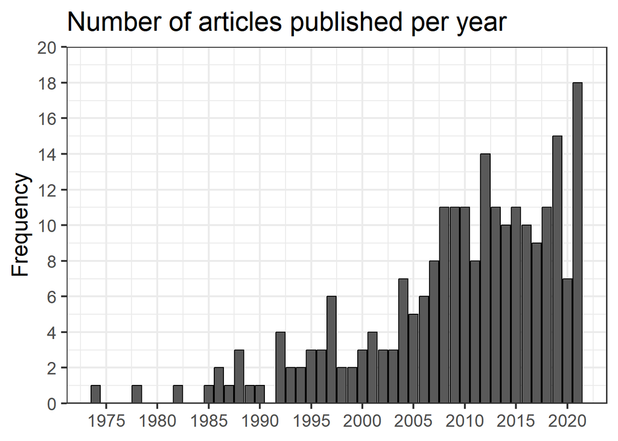

```r
data_articles <- data$Year |>
  table() |>
  as.data.frame()

data_articles$Var1 <- as.numeric(as.character(data_articles$Var1))

ggplot(data_articles, aes(x = Var1, y = Freq)) +
  geom_col(position = "stack", color = "black") +
  labs(
    title = "Number of articles published per year",
    x = NULL,
    y = "Frequency",
    fill = NULL
  ) +
  scale_y_continuous(breaks = seq(from = 0, to = 20, by = 2), expand = c(0,0), limits = c(0, 20)) +
  scale_x_continuous(breaks = seq(from = 1975, to = 2020, by =5)) +
  theme_bw(base_size = 18)
```

# Regressions

Here, we performed the regressions to understand the tendency of publications along the years.

It was necessary to control the amount of articles found for the review, by the amount of articles published in biology-related areas indexed in the Web of Science and Scopus databases.

**We considered only the years where articles elected for this review were published.** The numbers were all manually collected.

Number of articles published for Web of Science:

```r
correctionWOS <- c(1313, 2428, 4640, 5479, 5427, 5583, 5760, 6067, 7731, 21240, 21723, 23767, 25595, 27104, 29623, 33014, 31921, 31906, 35001, 35242, 37878, 38332, 41176, 47025, 52926, 56692, 62755, 63681, 70639, 71357, 76191, 79482, 85068, 93098, 99055, 121026, 140964, 163793, 178630)
```

Number of articles published for Scopus:

```r
correctionSCO <- c(18795, 23260, 29303, 35192, 35086, 36097, 38307, 41139, 44738, 46279, 48478, 52297, 55100, 74972, 78886, 79767, 80854, 83581, 85594, 90711, 94879, 99441, 110686, 122382, 134657, 144867, 153702, 162468, 179915, 189544, 201072, 205702, 214796, 214526, 222004, 231622, 239857, 263837, 284272)
```

I summed both corrections. There are probably some duplicates between databases, but the number of articles indexed in Scopus is so large that I could just subtract from Scopus the number of articles encountered in Web of Science, that it would not change the regression plot.

```r
correction.full <- correctionSCO + correctionWOS
```

Creating a new column with the correction:

```r
reg_data_articles <- data_articles  |>
  mutate(N = Freq/correction.full)
```

Function used to turn all values into scientific notation:

```r
scientific_10 <- function(x) {
  parse(text = gsub("e", " %*% 10^", scales::scientific_format()(x)))
}
```

Performing the linear regression, and showing the results:

```r
summary(lm(reg_data_articles$N ~ as.numeric(as.character(reg_data_articles$Var1))))
```

```
##
## Call:
## lm(formula = reg_data_articles$N ~ as.numeric(as.character(reg_data_articles$Var1)))
##
## Residuals:
##        Min         1Q     Median         3Q        Max
## -1.899e-05 -9.906e-06 -2.753e-06  9.945e-06  3.177e-05
##
## Coefficients:
##                                                    Estimate Std. Error t value
## (Intercept)                                       9.534e-05  3.401e-04   0.280
## as.numeric(as.character(reg_data_articles$Var1)) -2.970e-08  1.699e-07  -0.175
##                                                  Pr(>|t|)
## (Intercept)                                         0.781
## as.numeric(as.character(reg_data_articles$Var1))    0.862
##
## Residual standard error: 1.303e-05 on 37 degrees of freedom
## Multiple R-squared:  0.0008249,  Adjusted R-squared:  -0.02618
## F-statistic: 0.03055 on 1 and 37 DF,  p-value: 0.8622
```

Plotting both the linear and Loess regressions together:

[figure not shown]

```r
li.reg <- ggplot(reg_data_articles, aes(x = Var1, y = N)) +
  geom_point(size= 1.5) +
  geom_smooth(method = lm, colour="skyblue", fill="lightblue") +
  scale_y_continuous(labels = scientific_10, breaks = c(0, 2*10^-5, 3*10^-5, 4*10^-5, 5*10^-5, 6*10^-5, 7*10^-5)) +
  scale_x_continuous(breaks = seq(1975, 2020, 5), labels = seq(1975, 2020, 5)) +
  theme_classic(base_size = 15) +
  labs (title = "a)",
        x= NULL,
        y= "Number of articles controlled by\nthe total number of articles in WoS and Scopus\n") +
  theme(text = element_text(color = "black"), legend.title = element_blank()) +
  annotate("text", x = 1977, y = 6.5e-05, label = "    R² < 0.001\np = 0.89", size = 6)

lo.reg <- ggplot(reg_data_articles, aes(x = Var1, y = N)) +
  geom_point(size= 1.5) +
  geom_smooth(method = "loess", colour = "forestgreen", fill = "lightgreen", formula = "y ~ x") +
  scale_x_continuous(breaks = seq(1975, 2020, 5), labels = seq(1975, 2020, 5)) +
  theme_classic(base_size = 15) +
  labs (title = "b)",
        x= NULL,
        y= NULL) +
  theme(text = element_text(color = "black"), legend.title = element_blank(), axis.line.y = element_blank(), axis.title.y = element_blank(), axis.ticks.y = element_blank(), axis.text.y = element_blank())

li.reg + lo.reg + plot_annotation(
  title = "Publication trend over time:",
  theme = theme(plot.title = element_text(size = 15))
)
```

# Bar Graphs

## Spillmode x continent x factor inducing invasion

Factor inducing invasion by spillmode:

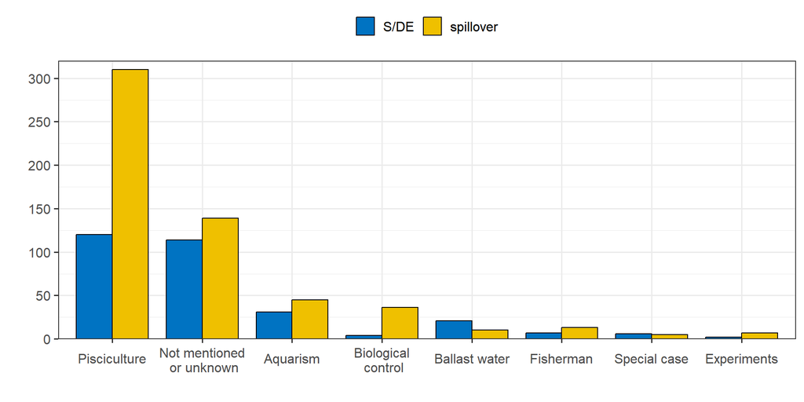

```r
fct.ind_records <- data |>
  ggplot(aes(x = fct_infreq(factor.ind), fill = Spillmode)) +
  geom_bar(position = "dodge", width = 0.8, color = "black") +
  scale_fill_jco(guide = guide_legend(nrow = 1)) +
  scale_y_continuous(expand = c(0, 0), limits = c(0, 320), breaks = seq(0, 300, 50)) +
  scale_x_discrete(labels = c("Pisciculture", "Not mentioned\n or unknown", "Aquarism", "Biological\n control", "Ballast water", "Fisherman", "Special case", "Experiments")) +
  labs(title = NULL,
       x = "",
       y = "") +
  theme_bw(base_size = 15) +
  theme(
    legend.title = element_blank(),
    legend.position = "inside",
    legend.position.inside = c(0.50, 0.96),
    legend.background = element_blank(),
    axis.title.x = element_blank(),
    axis.text.x = element_blank(),
    axis.ticks.x = element_blank(),
    axis.line.x = element_blank()
  ) +
  annotate(geom = "text", label = "A)", x = 8.3, y = 310)

data |>
  ggplot(aes(x = fct_infreq(factor.ind), fill = Spillmode)) +
  geom_bar(position = "dodge", width = 0.8, color = "black") +
  scale_fill_jco() +
  scale_y_continuous(expand = c(0, 0), limits = c(0, 320), breaks = seq(0, 300, 50)) +
  scale_x_discrete(labels = c("Pisciculture", "Not mentioned\n or unknown", "Aquarism", "Biological\n control", "Ballast water", "Fisherman", "Special case", "Experiments")) +
  labs(title = NULL,
       x = "",
       y = "") +
  theme_bw(base_size = 15) +
  theme(
    legend.title = element_blank(),
    legend.position = "top",
    legend.background = element_blank(),
    axis.text.x = element_text(angle = 0, vjust = 0.6),
  )
```

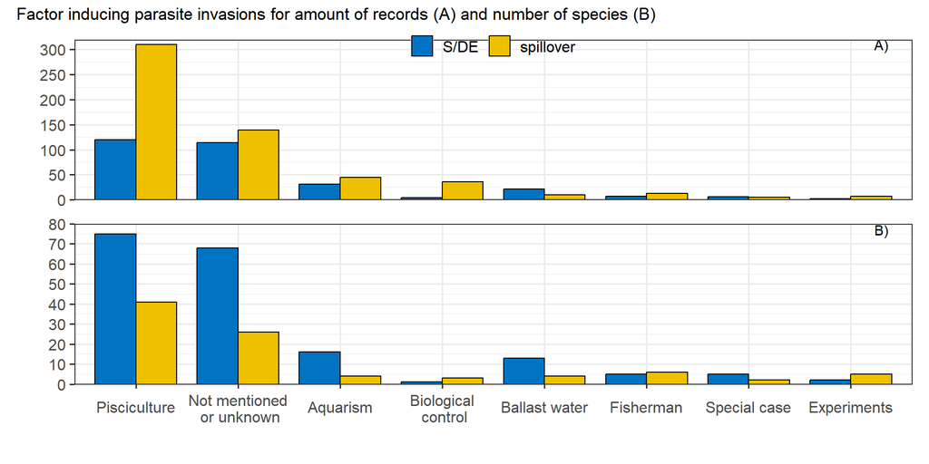

```r
fct.ind_species <- data |>
  group_by(factor.ind, Spillmode, psp) |>
  summarise(
    n = n(),
    .groups = "drop"
  ) |>
  mutate(
    factor.ind = fct_relevel(factor.ind, "Pisciculture", "Not mentioned or unknown", "Aquarism", "Biological control", "Ballast water", "Fisherman", "Special case", "Experiment")
  ) |>
  group_by(factor.ind, Spillmode) |>
  summarise(n = n(), .groups = "drop") |>
  ggplot(aes(x = factor.ind, y = n, fill = Spillmode)) +
  geom_bar(stat = "identity", position = "dodge", width = 0.8, color = "black") +
  scale_fill_jco() +
  scale_y_continuous(expand = c(0, 0), limits = c(0, 80), breaks = seq(0, 80, 10)) +
  scale_x_discrete(labels = c("Pisciculture", "Not mentioned\n or unknown", "Aquarism", "Biological\n control", "Ballast water", "Fisherman", "Special case", "Experiments")) +
  labs(title = NULL,
       x = "",
       y = "") +
  theme_bw(base_size = 15) +
  theme(
    legend.title = element_blank(),
    legend.position = "none",
    legend.background = element_blank(),
    axis.text.x = element_text(angle = 0, vjust = 0.6),
  ) +
  annotate(geom = "text", label = "B)", x = 8.3, y = 77)

fct.ind_records / fct.ind_species + plot_annotation(title = "Factor inducing parasite invasions for amount of records (A) and number of species (B)")
```

Factor inducing invasion by continent:

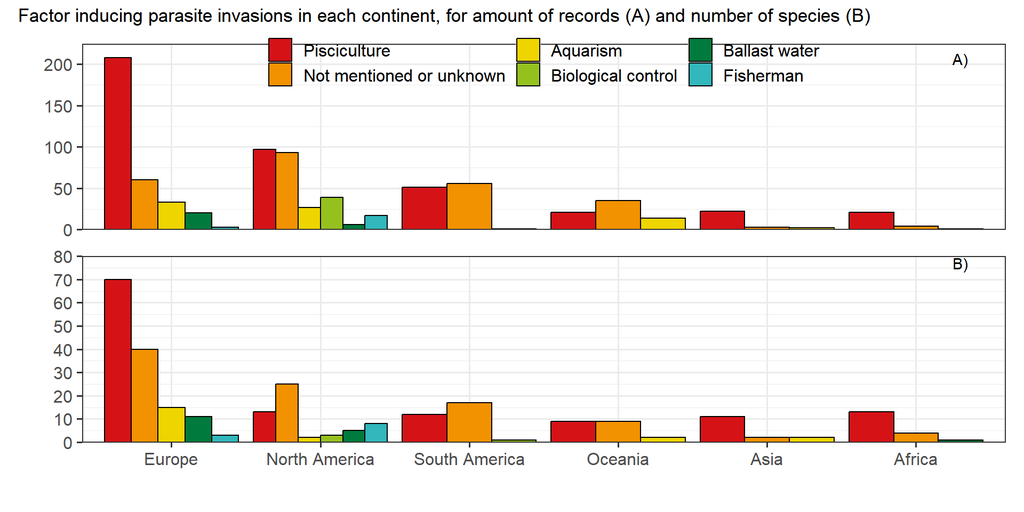

```r
fct.ind_continent_records <- data |>
  filter(
    continent != "Not applicable", # all "factor.ind == 'Experiment'" are removed here
    factor.ind != "Special case"   # removed because there are only 11 reports, 10 from Europe
  ) |>
  ggplot(aes(x = fct_infreq(continent), fill = fct_infreq(factor.ind))) +
  geom_bar(position = "dodge", color = "black") +
  scale_y_continuous(expand = c(0, 0), limits = c(0, 225), breaks = seq(0, 250, 50)) +
  scale_fill_frontiers(guide = guide_legend(nrow = 2)) +
  theme_bw(base_size = 15) +
  labs(title = NULL, x = "", y = "") +
  theme(
    legend.title = element_blank(),
    legend.position = "inside",
    legend.position.inside = c(0.50, 0.90),
    legend.background = element_blank(),
    axis.title.x = element_blank(),
    axis.text.x = element_blank(),
    axis.ticks.x = element_blank(),
    axis.line.x = element_blank()
  ) +
  annotate(geom = "text", label = "A)", x = 6.3, y = 207)

fct.ind_continent_species <- data |>
  filter(
    continent != "Not applicable",
    factor.ind != "Special case"
  ) |>
  group_by(factor.ind, continent, psp) |>
  summarise(
    n = n(),
    .groups = "drop"
  ) |>
  mutate(
    continent = fct_relevel(continent, "Europe", "North America", "South America", "Oceania", "Asia", "Africa"),
    factor.ind = fct_relevel(factor.ind, "Pisciculture", "Not mentioned or unknown", "Aquarism", "Biological control", "Ballast water", "Fisherman")
  ) |>
  group_by(factor.ind, continent) |>
  summarise(n = n(), .groups = "drop") |>
  ggplot(aes(x = continent, y = n, fill = factor.ind)) +
  geom_bar(stat = "identity", position = "dodge", color = "black") +
  scale_y_continuous(expand = c(0, 0), limits = c(0, 80), breaks = seq(0, 80, 10)) +
  scale_fill_frontiers() +
  theme_bw(base_size = 15) +
  labs(title = NULL, x = "", y = "") +
  theme(
    legend.title = element_blank(),
    legend.position = "none",
    legend.background = element_blank()
  ) +
  annotate(geom = "text", label = "B)", x = 6.3, y = 77)

fct.ind_continent_records / fct.ind_continent_species + plot_annotation(title = "Factor inducing parasite invasions in each continent, for amount of records (A) and number of species (B)")
```

Spillmode by continent:

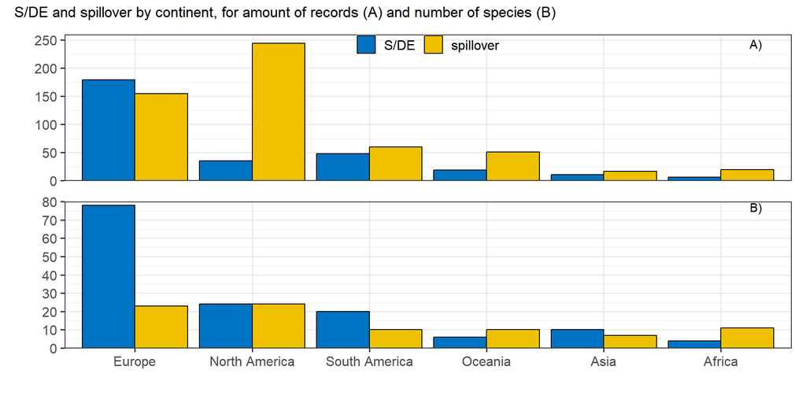

```r
spill.continent_records <- data |>
  filter(
    continent != "Not applicable", # all "factor.ind == 'Experiment'" are removed here
  ) |>
  ggplot(aes(x = fct_infreq(continent), fill = Spillmode)) +
  geom_bar(position = "dodge", color = "black") +
  scale_y_continuous(expand = c(0, 0), limits = c(0, 260), breaks = seq(0, 250, 50)) +
  scale_fill_jco(guide = guide_legend(nrow = 1)) +
  theme_bw(base_size = 15) +
  labs(title = NULL, x = "", y = "") +
  theme(
    legend.title = element_blank(),
    legend.position = "inside",
    legend.position.inside = c(0.50, 0.93),
    legend.background = element_blank(),
    axis.title.x = element_blank(),
    axis.text.x = element_blank(),
    axis.ticks.x = element_blank(),
    axis.line.x = element_blank()
  ) +
  annotate(geom = "text", label = "A)", x = 6.3, y = 243)

spill.continent_species <- data |>
  filter(
    continent != "Not applicable"
  ) |>
  group_by(Spillmode, continent, psp) |>
  summarise(
    n = n(),
    .groups = "drop"
  ) |>
  mutate(
    continent = fct_relevel(continent, "Europe", "North America", "South America", "Oceania", "Asia", "Africa"),
    ) |>
  group_by(Spillmode, continent) |>
  summarise(n = n(), .groups = "drop")  |>
  ggplot(aes(x = fct_infreq(continent), y = n, fill = Spillmode)) +
  geom_bar(stat = "identity", position = "dodge", color = "black") +
  scale_y_continuous(expand = c(0, 0), limits = c(0, 80), breaks = seq(0, 80, 10)) +
  scale_fill_jco() +
  theme_bw(base_size = 15) +
  labs(title = NULL, x = "", y = "") +
  theme(
    legend.title = element_blank(),
    legend.position = "none",
    legend.background = element_blank()
  ) +
  annotate(geom = "text", label = "B)", x = 6.3, y = 77)

spill.continent_records / spill.continent_species + plot_annotation(title = "S/DE and spillover by continent, for amount of records (A) and number of species (B)")
```

## Parasite specialist or generalist nature

In this section we built the graphs illustrating whether the parasites were considered specialist or generalist in literature, plus if we found it infecting more than one host family or host order in this review.

We removed all parasites that were registered only once, since it would inflate the frequency of parasites infecting only one fish family/order. Among all 186 parasite species, 88 were registered only once.

```r
pstyle_plot <- data |>
  group_by(psp) |>
  filter(n() > 1) |>        # Keep only species with more than one occurrence
  ungroup() |>
  group_by(pstyle, psp, ambiguous, N.host.families, N.host.orders) |>
  summarise(
    n = n(),
    .groups = "drop"
  ) |>
  mutate(
    NumberFamilies = case_when(
      N.host.families == 1 ~ factor("One"),
      N.host.families > 1 & N.host.families <= 5 ~ factor("More than one"),
      N.host.families > 5 ~ factor("More than five")
    ),
    NumberOrders = case_when(
      N.host.orders == 1 ~ factor("One"),
      N.host.orders > 1 & N.host.orders <= 5 ~ factor("More than one"),
      N.host.orders > 5 ~ factor("More than five")
    )
  )
```

Graph for the amount of fish families infected:

```r
nfamilies <- pstyle_plot |>
  ggplot(aes(x = pstyle, fill = NumberFamilies)) +
  geom_bar(stat = "count", position = "dodge", color= "black") +
  theme_bw(base_size = 15) +
  scale_fill_tron() +
  scale_y_continuous(
    expand = c(0, 0),
    limits = c(0, 42),
    breaks = seq(0, 40, 10)
  ) +
  labs(
    y = NULL,
    x = NULL,
    title = "a) Number of host families",
    #subtitle = "*for parasites registered more than once",
    fill = NULL
  ) +
  theme(
    legend.position = "none",
    plot.margin = unit(c(0, 0, 0, 0), "cm")
  )
```

Graph for the amount of orders infected:

```r
norders <- pstyle_plot |>
  ggplot(aes(x = pstyle, fill = NumberOrders)) +
  geom_bar(stat = "count", position = "dodge", color= "black") +
  theme_bw(base_size = 15) +
  scale_fill_tron() +
  scale_y_continuous(
    expand = c(0, 0),
    limits = c(0, 42),
    breaks = seq(0, 40, 10)
  ) +
  labs(
    y = NULL,
    x = NULL,
    title = "b) Number of host orders",
    fill = NULL
  ) +
  theme(
    plot.margin = unit(c(0, 0, 0, 0), "cm"),
    axis.title.y = element_blank(),
    axis.text.y = element_blank(),
    axis.ticks.y = element_blank(),
    axis.line.y = element_blank(),
    legend.position = "inside",
    legend.background = element_blank(),
    legend.position.inside = c(0.78,0.88)
  )
```

Plotting both together:

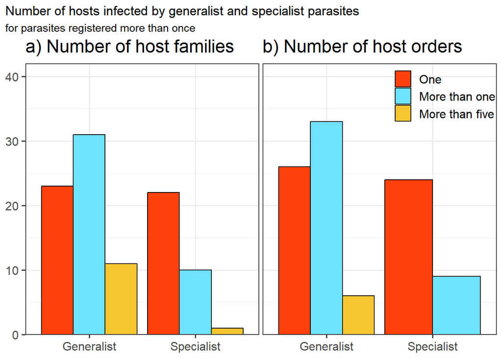

```r
nfamilies + norders + plot_annotation(title = "Number of hosts infected by generalist and specialist parasites", subtitle = "for parasites registered more than once")
```

## Fish order and parasite phyla proportions

For this graph, we used both the number of registers and the number of species.

Parasite phyla proportions:

```r
pphyla.registers <- data |>
  group_by(pphy) |>
  summarise(
    n = n(),
    .groups = "drop"
  ) |>
  inner_join(
    data |>
      group_by(Spillmode, pphy) |>
      summarise(
        n = n(),
        .groups = "drop"
      ),
    by = "pphy"
  ) |>
  mutate(
    proportion = n.x / sum(n.x)*100,
    rel_proportion = n.y / sum(n.y)*100
  ) |>
  ggplot(
    aes(
      x = reorder(pphy, proportion),
      y = rel_proportion,
      fill = Spillmode,
    )
  ) +
  geom_bar(stat = "identity", position = "dodge", color= "black") +
  coord_flip() +
  theme_bw(base_size = 12) +
  scale_fill_jco() +
  scale_y_continuous(expand = c(0, 0), limits = c(0, 35.5), labels = label_percent(scale = 1), breaks = seq(0, 35, 5)) +
  labs(y = NULL, x = NULL, fill = NULL, title = "b) Amount of parasite recorded") +
  theme(legend.position = "none",
        legend.position.inside = c(0.75, 0.15),
        legend.background = element_blank(),
        plot.margin = unit(c(0, 0, 0, 0.3), "cm"),
        axis.text.x = element_blank(),
        axis.ticks.x = element_blank())

pphyla.species <- data |>
  group_by(pphy, psp) |>
  summarise(
    n = n(),
    .groups = "drop"
  ) |>
  group_by(pphy) |>
  summarise(n = n()) |>
  inner_join(
    data |>
      group_by(Spillmode, pphy, psp) |>
      summarise(
        n = n(),
        .groups = "drop"
      ) |>
      group_by(Spillmode, pphy) |>
      summarise(n = n(), .groups = "drop"),
    by = "pphy"
  ) |>
  mutate(
    proportion = n.x / sum(n.x)*100,
    rel_proportion = n.y / sum(n.y)*100,
    pphy = fct_relevel(pphy, "Euglenozoa", "Negarnaviricota", "Metamonada", "Microsporidia", "Nucleocytoviricota", "Annelida", "Choanozoa", "Cnidaria", "Oomycota", "Ciliophora", "Acanthocephala", "Arthropoda", "Nematoda", "Platyhelminthes")
  ) |>
  ggplot(
    aes(
      x = reorder(pphy, proportion),
      y = rel_proportion,
      fill = Spillmode,
    )
  ) +
  geom_bar(stat = "identity", position = "dodge", color= "black") +
  coord_flip() +
  theme_bw(base_size = 12) +
  scale_fill_jco() +
  scale_y_continuous(expand = c(0, 0), limits = c(0, 35.5), labels = label_percent(scale = 1), breaks = seq(0, 35, 5)) +
  labs(y = NULL, x = NULL, fill = NULL, title = "d) Number of parasite species") +
  theme(legend.position = "inside", legend.position.inside = c(0.75, 0.15), legend.background = element_blank(),
        plot.margin = unit(c(0, 0, 0, 0.3), "cm"))
```

Fish order proportions:

```r
forder.registers <- data |>
  group_by(horder) |>
  summarise(
    n = n(),
    .groups = "drop"
  ) |>
  inner_join(
    data |>
      group_by(Spillmode, horder) |>
      summarise(
        n = n(),
        .groups = "drop"
      ),
    by = "horder"
  ) |>
  mutate(
    proportion = n.x / sum(n.x)*100,
    rel_proportion = n.y / sum(n.y)*100
  ) |>
  ggplot(
    aes(
      x = reorder(horder, proportion),
      y = rel_proportion,
      fill = Spillmode,
    )
  ) +
  geom_bar(stat = "identity", position = "dodge", color= "black") +
  coord_flip() +
  theme_bw(base_size = 12) +
  scale_fill_jco() +
  scale_y_continuous(expand = c(0, 0), limits = c(0, 22.5), labels = label_percent(scale = 1), breaks = seq(0, 20, 5)) +
  labs(y = NULL, x = NULL, fill = NULL, title = "a) Amount of host recorded") +
  theme(legend.position = "none",
        legend.background = element_blank(),
        plot.margin = unit(c(0, 0, 0, 0), "cm"),
        axis.text.x = element_blank(),
        axis.ticks.x = element_blank())

forder.species <- data |>
  group_by(horder, hsp) |>
  summarise(
    n = n(),
    .groups = "drop"
  ) |>
  group_by(horder) |>
  summarise(n = n()) |>
  inner_join(
    data |>
      group_by(Spillmode, horder, hsp) |>
      summarise(
        n = n(),
        .groups = "drop"
      ) |>
      group_by(Spillmode, horder) |>
      summarise(n = n(), .groups = "drop"),
    by = "horder"
  ) |>
  mutate(
    proportion = n.x / sum(n.x)*100,
    rel_proportion = n.y / sum(n.y)*100,
    horder = fct_relevel(horder, "Blenniiformes", "Esociformes", "Gadiformes", "Kurtiformes", "Scorpaeniformes", "Synbranchiformes", "Osmeriformes", "Pleuronectiformes", "Anabantiformes", "Mugiliformes", "Clupeiformes", "Galaxiiformes", "Characiformes", "Atheriniformes", "Siluriformes", "Perciformes", "Cichliformes", "Cyprinodontiformes", "Salmoniformes", "Centrarchiformes", "Anguilliformes", "Cypriniformes", "Gobiiformes")
  ) |>
  ggplot(
    aes(
      x = reorder(horder, proportion),
      y = rel_proportion,
      fill = Spillmode,
    )
  ) +
  geom_bar(stat = "identity", position = "dodge", color= "black") +
  coord_flip() +
  theme_bw(base_size = 12) +
  scale_fill_jco() +
  scale_y_continuous(expand = c(0, 0), limits = c(0, 22.5), labels = label_percent(scale = 1), breaks = seq(0, 20, 5)) +
  labs(y = NULL, x = NULL, fill = NULL, title = "c) Number of host species") +
  theme(legend.position = "none",
        legend.background = element_blank(),
        plot.margin = unit(c(0, 0, 0, 0), "cm"))
```

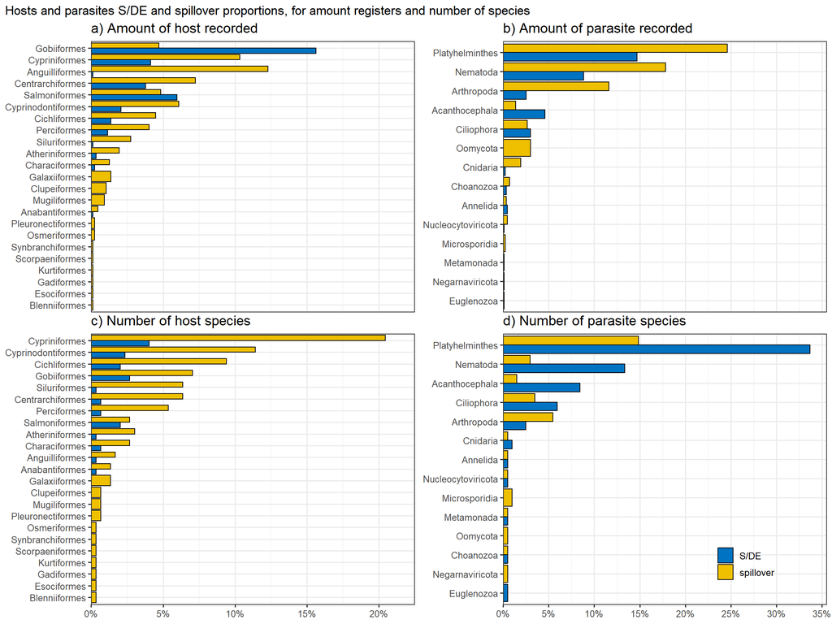

```r
(forder.registers + pphyla.registers) / (forder.species + pphyla.species) + plot_annotation(title = "Hosts and parasites S/DE and spillover proportions, for amount registers and number of species")
```

## Parasite functional traits proportions

For life cycle, regarding whether the parasite (record and species) was heteroxenous or monoxenous, by spillmode:

```r
spill_lc.records <- data |>
  group_by(Life.cycle, Spillmode) |>
  summarise(n = n(), .groups = "drop") |>
  mutate(percent = n / sum(n)*100) |>
  rename(trait = Life.cycle)

slc.records <- ggplot(spill_lc.records, aes(x = trait, y = percent, fill = Spillmode)) +
  geom_bar(stat = "identity", position = "stack", color = "black", width = 0.8) +
  scale_fill_jco() +
  theme_bw(base_size = 15) +
  scale_y_continuous(
    expand = c(0, 0),
    limits = c(0, 82),
    labels = c("0%", "10%", "20%", "30%", "40%", "50%", "60%", "70%", "80%"),
    breaks = seq(0, 80, 10)
  ) +
  labs(
    y = NULL, x = NULL, fill = NULL
  ) +
  theme(
    legend.position = "none",
    plot.margin = unit(c(0, 0, 0.05, 0), "cm"),
    axis.title.x = element_blank(),
    axis.text.x = element_blank(),
    axis.ticks.x = element_blank(),
    axis.line.x = element_blank(),
  ) +
  annotate(geom = "text", label = "A)", x = 0.5, y = 77)

spill_lc.species <- data |>
  group_by(Life.cycle, Spillmode, psp) |>
  summarise(n = n(), .groups = "drop") |>
  group_by(Life.cycle, Spillmode) |>
  summarise(n = n(), .groups = "drop") |>
  mutate(percent = n / sum(n)*100) |>
  rename(trait = Life.cycle)

slc.species <- ggplot(spill_lc.species, aes(x = trait, y = percent, fill = Spillmode)) +
  geom_bar(stat = "identity", position = "stack", color = "black", width = 0.8) +
  scale_fill_jco() +
  theme_bw(base_size = 15) +
  scale_y_continuous(
    expand = c(0, 0),
    limits = c(0, 82),
    labels = c("0%", "10%", "20%", "30%", "40%", "50%", "60%", "70%", "80%"),
    breaks = seq(0, 80, 10)
  ) +
  labs(
    y = NULL, x = NULL, fill = NULL
  ) +
  theme(
    legend.position = "none",
    plot.margin = unit(c(0, 0, 0, 0), "cm")
  ) +
  annotate(geom = "text", label = "B)", x = 0.5, y = 77)
```

For site of infection, regarding if the parasite species was an ecto or endoparasite, by spillmode:

```r
spill_loc.records <- data |>
  group_by(Ecto.or.Endo, Spillmode) |>
  summarise(n = n(), .groups = "drop") |>
  mutate(percent = n / sum(n)*100) |>
  rename(trait = Ecto.or.Endo)

sl.records <- ggplot(spill_loc.records, aes(x = trait, y = percent, fill = Spillmode)) +
  geom_bar(stat = "identity", position = "stack", color = "black", width = 0.8) +
  scale_fill_jco() +
  theme_bw(base_size = 15) +
  scale_y_continuous(
    expand = c(0, 0),
    limits = c(0, 82),
    labels = c("0%", "10%", "20%", "30%", "40%", "50%", "60%", "70%", "80%"),
    breaks = seq(0, 80, 10)
  ) +
  labs(
    y = NULL, x = NULL, fill = NULL
  ) +
  theme(
    legend.position = "none",
    axis.title.y = element_blank(),
    axis.text.y = element_blank(),
    axis.ticks.y = element_blank(),
    axis.line.y = element_blank(),
    axis.title.x = element_blank(),
    axis.text.x = element_blank(),
    axis.ticks.x = element_blank(),
    axis.line.x = element_blank(),
    plot.margin = unit(c(0, 0, 0, 0), "cm")
  )

spill_loc.species <- data |>
  group_by(Ecto.or.Endo, Spillmode, psp) |>
  summarise(n = n(), .groups = "drop") |>
  group_by(Ecto.or.Endo, Spillmode) |>
  summarise(n = n(), .groups = "drop") |>
  mutate(percent = n / sum(n)*100) |>
  rename(trait = Ecto.or.Endo)

sl.species <- ggplot(spill_loc.species, aes(x = trait, y = percent, fill = Spillmode)) +
  geom_bar(stat = "identity", position = "stack", color = "black", width = 0.8) +
  scale_fill_jco() +
  theme_bw(base_size = 15) +
  scale_y_continuous(
    expand = c(0, 0),
    limits = c(0, 82),
    labels = c("0%", "10%", "20%", "30%", "40%", "50%", "60%", "70%", "80%"),
    breaks = seq(0, 80, 10)
  ) +
  labs(
    y = NULL, x = NULL, fill = NULL
  ) +
  theme(
    legend.position = "none",
    axis.title.y = element_blank(),
    axis.text.y = element_blank(),
    axis.ticks.y = element_blank(),
    axis.line.y = element_blank(),
    plot.margin = unit(c(0, 0, 0, 0), "cm")
  )
```

For parasite specialization, regarding if it is a specialist, generalist or if this trait was not identified, by spillmode:

```r
spill_style.records <- data |>
  group_by(pstyle, Spillmode) |>
  summarise(n = n(), .groups = "drop") |>
  mutate(
    percent = n / sum(n)*100,
    pstyle = factor(pstyle, levels = c("Generalist", "Specialist", "Not identified"))
  ) |>
  rename(trait = pstyle)

ss.records <- ggplot(spill_style.records, aes(x = trait, y = percent, fill = Spillmode)) +
  geom_bar(stat = "identity", position = "stack", color = "black", width = 0.8) +
  scale_fill_jco() +
  theme_bw(base_size = 15) +
  scale_y_continuous(
    expand = c(0, 0),
    limits = c(0, 82),
    labels = c("0%", "10%", "20%", "30%", "40%", "50%", "60%", "70%", "80%"),
    breaks = seq(0, 80, 10)
  ) +
  labs(
    y = NULL, x = NULL, fill = NULL
  ) +
  theme(
    legend.position = "inside",
    legend.position.inside = c(0.99, 1),
    legend.justification = c(1, 1),
    legend.background = element_blank(),
    axis.title.y = element_blank(),
    axis.text.y = element_blank(),
    axis.ticks.y = element_blank(),
    axis.line.y = element_blank(),
    axis.title.x = element_blank(),
    axis.text.x = element_blank(),
    axis.ticks.x = element_blank(),
    axis.line.x = element_blank(),
    plot.margin = unit(c(0, 0, 0, 0), "cm")
  )

spill_style.species <- data |>
  group_by(pstyle, Spillmode, psp) |>
  summarise(n = n(), .groups = "drop") |>
  group_by(pstyle, Spillmode) |>
  summarise(n = n(), .groups = "drop") |>
  mutate(percent = n / sum(n)*100) |>
  rename(trait = pstyle)

ss.species <- ggplot(spill_style.species, aes(x = trait, y = percent, fill = Spillmode)) +
  geom_bar(stat = "identity", position = "stack", color = "black", width = 0.8) +
  scale_fill_jco() +
  theme_bw(base_size = 15) +
  scale_y_continuous(
    expand = c(0, 0),
    limits = c(0, 82),
    labels = c("0%", "10%", "20%", "30%", "40%", "50%", "60%", "70%", "80%"),
    breaks = seq(0, 80, 10)
  ) +
  labs(
    y = NULL, x = NULL, fill = NULL
  ) +
  theme(
    legend.position = "none",
    legend.background = element_blank(),
    axis.title.y = element_blank(),
    axis.text.y = element_blank(),
    axis.ticks.y = element_blank(),
    axis.line.y = element_blank(),
    plot.margin = unit(c(0, 0, 0, 0), "cm")
  )
```

Plotting all together:

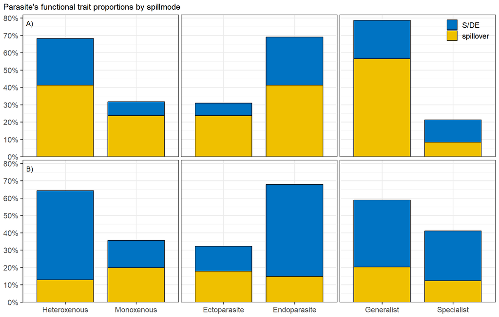

```r
(slc.records + sl.records + ss.records) / (slc.species + sl.species + ss.species) + plot_annotation(title = "Parasite's functional trait proportions by spillmode")
```

## Data for host traits (**Table 2**)

For host feeding habit:

```r
hfeed <- data |>
  group_by(host.feeding) |>
  summarise(unique_sp = n_distinct(hsp), .groups = "drop") |>
  mutate(percent = unique_sp / sum(unique_sp)*100) |>
  rename(trait = host.feeding)
```

For host migration behavior:

```r
hmigr <- data |>
  group_by(Migrant) |>
  summarise(unique_sp = n_distinct(hsp), .groups = "drop") |>
  mutate(percent = unique_sp / sum(unique_sp)*100) |>
  rename(trait = Migrant)
```

For host schooling or shoaling behavior:

```r
hscho <- data |>
  group_by(shchooling) |>
  summarise(unique_sp = n_distinct(hsp), .groups = "drop") |>
  mutate(percent = unique_sp / sum(unique_sp)*100) |>
  rename(trait = shchooling)
```

For host IUCN status:

```r
hstatus <- data |>
  group_by(status) |>
  summarise(unique_sp = n_distinct(hsp), .groups = "drop") |>
  mutate(percent = unique_sp / sum(unique_sp)*100) |>
  rename(trait = status)
```

The host table:

```r
general.host.table <- rbind(hfeed, hmigr, hscho, hstatus)
general.host.table
```

```
## # A tibble: 20 × 3
##    trait                 unique_sp percent
##    <chr>                     <int>   <dbl>
##  1 Carnivorous                  86  32.8
##  2 Detritivorous                 2   0.763
##  3 Herbivorous                  17   6.49
##  4 Insectivorous                24   9.16
##  5 Omnivorous                  101  38.5
##  6 Piscivorous                   6   2.29
##  7 Unknown                      26   9.92
##  8 No                          122  46.6
##  9 Unknown                      71  27.1
## 10 Yes                          69  26.3
## 11 No                           45  17.2
## 12 Unknown                     126  48.1
## 13 Yes                          91  34.7
## 14 Critically endangered         5   1.91
## 15 Data deficient                7   2.67
## 16 Endangered                   23   8.78
## 17 Least concern               182  69.5
## 18 Near threatened              11   4.20
## 19 Not evaluated                18   6.87
## 20 Vulnerable                   16   6.11
```

# Networks

## Sankey diagrams

Sankey diagram for origin and invaded area for spillover parasites

For the Sankey diagram, its needed two data frames, which will have important comments.

**1)** the first is the count of links between native and invaded countries:

```r
spillover <- data |>
  filter(
    lab %in% c("No"),
    meltdown %in% c("No"), # Invasion meltdown events (n = 81) were removed, of which 50 are from fishes native to Asia.
    Spillmode == "spillover",
    original.host.continent %in% c("Africa", "Asia", "Europe", "North America", "Oceania", "South America") # There are some parasites and hosts that have a unknown distribution or native range. Some of them had a vast distribution like "northern hemisphere", "Atlantic Ocean", etc. In both cases, that accounted for 109 registers that were removed for this diagram. I accounted only the ones that had a distribution inside the continents.
  ) |>
  select(
    original.host.continent,
    continent
  ) |>
  as_tibble()

spillover_links <- spillover |>
  count(original.host.continent, continent) |>
  mutate(continent = str_c(continent, " ")) # The spacing is needed, so the invaded and native continents will be different even having the same name.
```

```r
spillover_nodes <- data.frame(
  nodes = c(
    as.character(spillover_links$original.host.continent),
    spillover_links$continent
  ) |>
    unique()
)

spillover_links <- spillover_links |>
  mutate(
    IDsource = match(spillover_links$original.host.continent, spillover_nodes$nodes)-1,
    IDtarget = match(spillover_links$continent, spillover_nodes$nodes)-1
  )
```

Plotting the diagram:

```r
sankeyNetwork(Links = spillover_links, Nodes = spillover_nodes,
              Source = "IDsource", Target = "IDtarget",
              Value = "n", NodeID = "nodes",
              sinksRight = T, nodeWidth = 40, fontSize = 13)
```

```
## Links is a tbl_df. Converting to a plain data frame.
```

[interactive chart not shown]

## Network with ‘bipartite’

Bipartite network for host and parasite species (species-species netwok):

```r
network <- data |>
  select(horder, pphy, hsp, psp) |>
  mutate(nothing = "")  # creating an empty column because frame2webs function requires to specify the network community even if I'm working with just one community, and I don't know how to handle this otherwise.

network_sp <- frame2webs(network, varnames = c("hsp", "psp", "nothing"), type.out = "array") |>
  as.data.frame()
```

Reordering is needed to see the nestedness pattern in the network:

```r
network_sp <- network_sp[order(rowSums(network_sp), decreasing = T), order(colSums(network_sp), decreasing = T)]
```

Plotting the network:

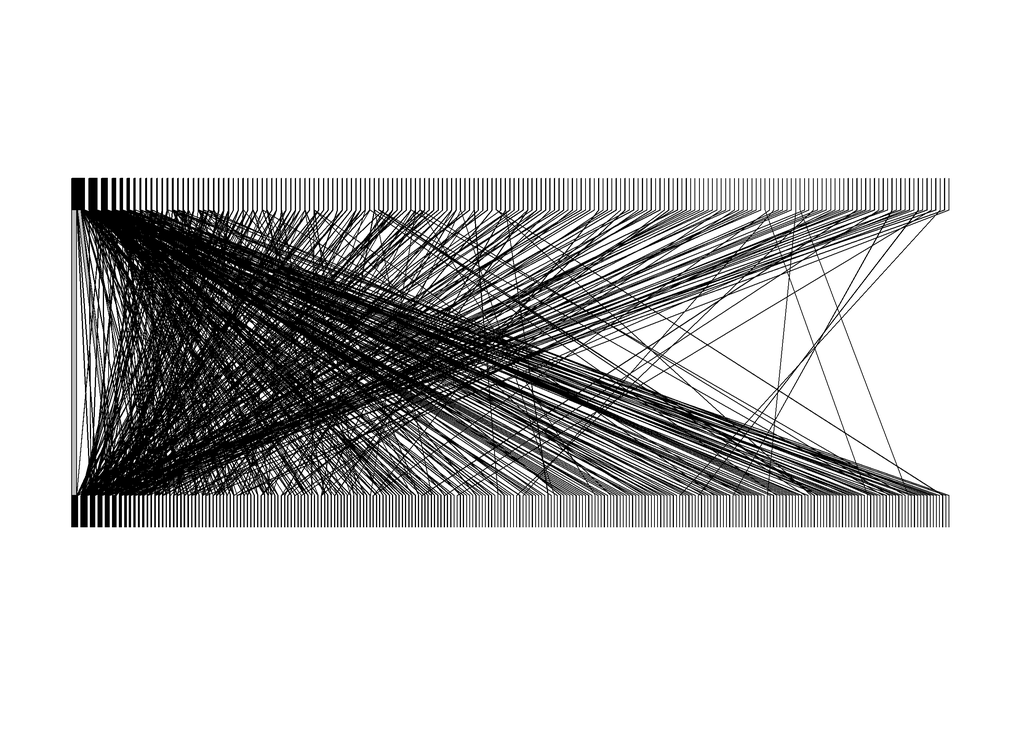

```r
plotweb(network_sp, method = "normal", y.width.low = 0.05, y.width.high = 0.05, y.lim = c(0, 1.92), arrow = "no", col.low = "black", bor.col.low = "black", col.high = "black", bor.col.high = "black", col.interaction = "grey", bor.col.interaction = "black", high.lablength = 0, low.lablength = 0)
```

## Network with ‘igraph’

This is an one mode projection network. It will show connected host species that share parasite species in common.

First, its needed to set a color for each host species:

```r
node_colors <- paletteer_d("ggsci::default_igv")[0:23] # It's a vector of 23 color codes, one for each host order.

order_colors <- data.frame(
  horder = unique(data$horder),
  color = node_colors
)
```

And then join the colors to the dataframe:

```r
data_colors <- data |>
  left_join(order_colors, join_by(horder))
```

For the one mode projection for S/DE registers:

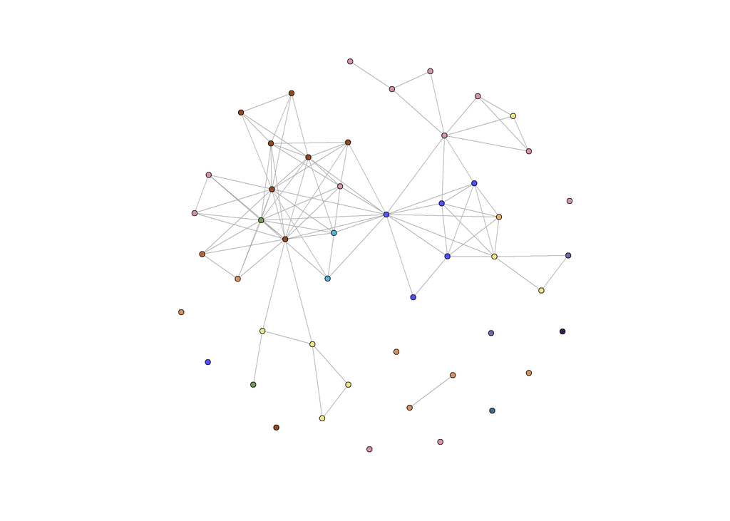

```r
# Creating the S/DE network.
spillback_1mode <- data |>
  filter(Spillmode == "S/DE") |>
  select(hsp, psp) |>
  graph_from_data_frame(directed = F)

# It was needed to set this network as a bipartite network
V(spillback_1mode)$type <- bipartite.mapping(spillback_1mode)$type
# Then, it was possible to use this function to made a one mode projection.
# $proj1 is the one mode network for hosts, while $proj2 is for parasites.
proj_spillback <- bipartite.projection(spillback_1mode)$proj1
# Imputing the color for each node
V(proj_spillback)$color <- data_colors$color[match(V(proj_spillback)$name, data_colors$hsp)]

# Setting the layout (from 'qgraph')
lb <- qgraph.layout.fruchtermanreingold(get.edgelist(proj_spillback, names = FALSE), vcount = vcount(proj_spillback), area = 8*(vcount(proj_spillback)^2), repulse.rad = (vcount(proj_spillback)^3.1))
plot(proj_spillback, layout = lb, vertex.label.color = "black", vertex.size = 3, vertex.label = NA)
```

For the one mode projection for spillover registers:

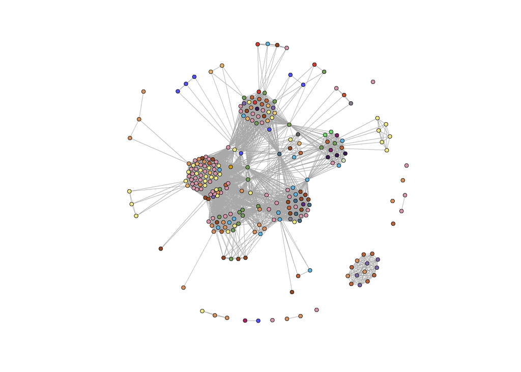

```r
# Creating the spillover network.
spillover_1mode <- data |>
  filter(Spillmode == "spillover") |>
  select(hsp, psp) |>
  graph_from_data_frame(directed = F)

# Exactly the same things done for S/DE will be done in here for spillover
V(spillover_1mode)$type <- bipartite.mapping(spillover_1mode)$type

proj_spillover <- bipartite.projection(spillover_1mode)$proj1

V(proj_spillover)$color <- data_colors$color[match(V(proj_spillover)$name, data_colors$hsp)]

lo <- qgraph.layout.fruchtermanreingold(get.edgelist(proj_spillover, names = FALSE), vcount = vcount(proj_spillover), area = 8*(vcount(proj_spillover)^2), repulse.rad = (vcount(proj_spillover)^3.1))

plot(proj_spillover, layout = lo, vertex.label.color = "black", vertex.size = 3, vertex.label = NA)
```

## Network metrics

This was the code used to find the network indexes described for the full network (with S/DE and spillover events), for host and parasite species:

```
data |>
  select(hsp, psp) |>
  mutate(nothing = "") |>
  frame2webs(varnames = c("hsp", "psp", "nothing"), type.out = "array") |>
  as.data.frame() |>
  networklevel(index = "ALL")
```

I didn’t run the results in this document, because it would take a long time to do so!

# World map

The world countries shape was downloaded from >http://tapiquen-sig.jimdo.com< *Carlos Efraín Porto Tapiquén. Orogénesis Soluciones Geográficas. Porlamar, Venezuela 2015. Based on shapes from Enviromental Systems Research Institute (ESRI). Free Distribuition.*

Reading the shape file:

```r
countries <- read_sf("World_Countries.shp")
countries$COUNTRY[countries$COUNTRY == "New Caledonia (France)"] <- "New Caledonia" # just adjusting this country name
```

Changing some country names in my dataset so it will fit with the “countries” object:

```r
data_map <- data  |>
  mutate(country = gsub("USA", "United States", country)) |>
  mutate(country = gsub("(England|Scotland|Wales|Ireland|Isle of Man)", "United Kingdom", country)) |>
  rename(COUNTRY = country) |>
  filter(COUNTRY != "Not applicable")
```

Percent of invasion registers per country (Supplementary material 3):

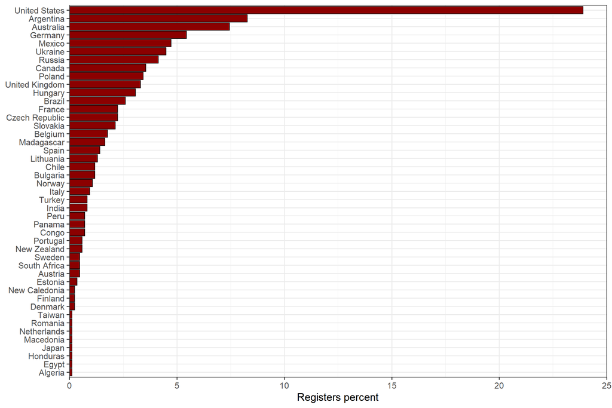

```r
data_map  |>
  group_by(COUNTRY)  |>
  summarise(n = n())  |>
  mutate(percent = n / sum(n) * 100) |>
  ggplot(aes(x = reorder(COUNTRY, percent), y = percent)) +
  geom_col(color = "black", fill = "darkred") +
  labs(x = NULL, y = "Registers percent") +
  scale_y_continuous(expand = c(0, 0), limits = c(0, 25)) +
  coord_flip() +
  theme_bw(base_size = 15)
```

Percent of spillmode by country:

```r
spillcount <- data_map |>
  count(Spillmode, COUNTRY) |>
  group_by(COUNTRY) |>
  mutate(percent = n / sum(n) * 100)

country_coords <- countries |>
  full_join(spillcount, join_by(COUNTRY)) |>
  mutate(
    n = ifelse(is.na(n), 0, n),
    percent = ifelse(is.na(percent), 0, percent)
  )
```

Taking the coordinates for the center of each country (which will be the piechart positions)

```r
centroids <- st_centroid(country_coords$geometry)
country_coords$lat <- st_coordinates(centroids)[,2]
country_coords$long <- st_coordinates(centroids)[,1]

country_coords <- country_coords |>
  mutate(
    lat = ifelse(COUNTRY == "United States", 38.5, lat), # Adjusting the USA and Canada coordinates was needed, so the piechart is displayied the center +
    long = ifelse(COUNTRY == "United States", -95.7129, long),
    lat = ifelse(COUNTRY == "Canada", 59.4371435, lat),
    long = ifelse(COUNTRY == "Canada", -105, long),
    cumsum = ave(n, Spillmode, FUN = cumsum), # Adding the cummulative sum and total sum of the number of registers
    total = ave(n, Spillmode, FUN = sum),
    start = 2 * pi * cumsum(percent) / 100 - 2 * pi * percent / 100, # Adding the start and end points of the charts.
    end = 2 * pi * cumsum(percent) / 100,
    sum_n = ave(n, COUNTRY, FUN = sum)
  )
```

Plotting the map for amunt of records:

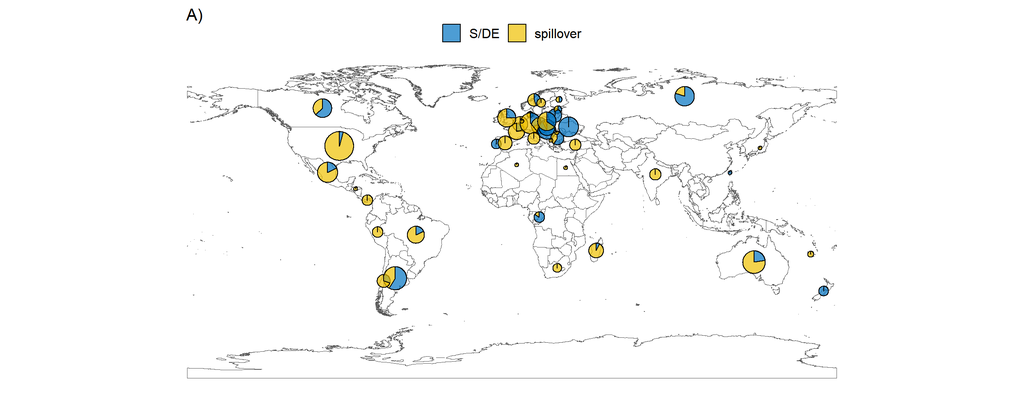

```r
map_records <- ggplot() +
  geom_sf(data = country_coords, fill = "white") +
  geom_arc_bar(
    data = filter(country_coords, !is.na(Spillmode)),
    aes(x0 = long, y0 = lat, r0 = 0, r = 1.5*log(sum_n+1),
        start = start,
        end = end,
        fill = Spillmode),
    alpha = 0.7
  ) +
  scale_fill_jco(guide = guide_legend(nrow = 1)) +
  theme_void(base_size = 15) +
  theme(legend.position = "top") +
  guides(fill = guide_legend(title = NULL)) +
  labs(subtitle = "       A)")
map_records
```

Organizing data for plotting the world map with species number:

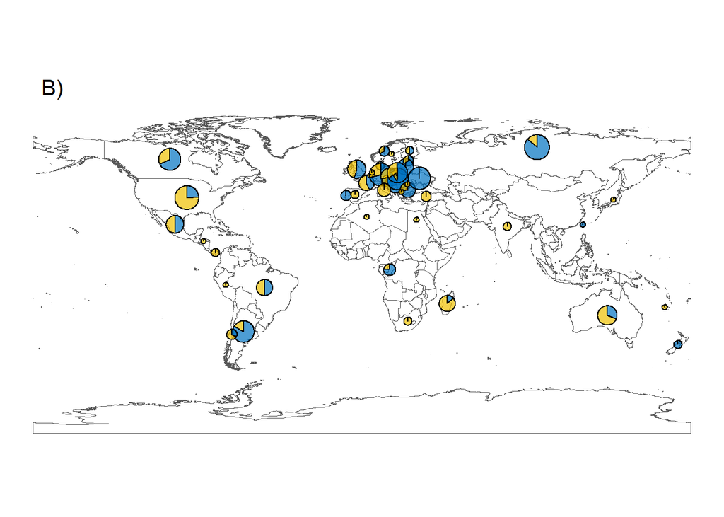

```r
spillcount2 <- data_map |>
  group_by(COUNTRY, psp, Spillmode) |>
  summarise(n = n(), .groups = "drop") |>
  group_by(COUNTRY, Spillmode) |>
  summarise(n = n(), .groups = "drop") |>
  group_by(COUNTRY) |>
  mutate(percent = n / sum(n) * 100) |>
  ungroup()

country_coords2 <- countries |>
  full_join(spillcount2, join_by(COUNTRY)) |>
  mutate(
    n = ifelse(is.na(n), 0, n),
    percent = ifelse(is.na(percent), 0, percent)
  )

centroids2 <- st_centroid(country_coords2$geometry)
country_coords2$lat <- st_coordinates(centroids2)[,2]
country_coords2$long <- st_coordinates(centroids2)[,1]

country_coords2 <- country_coords2 |>
  mutate(
    lat = ifelse(COUNTRY == "United States", 38.5, lat),
    long = ifelse(COUNTRY == "United States", -95.7129, long),
    lat = ifelse(COUNTRY == "Canada", 59.4371435, lat),
    long = ifelse(COUNTRY == "Canada", -105, long),
    cumsum = ave(n, Spillmode, FUN = cumsum),
    total = ave(n, Spillmode, FUN = sum),
    start = 2 * pi * cumsum(percent) / 100 - 2 * pi * percent / 100,
    end = 2 * pi * cumsum(percent) / 100,
    sum_n = ave(n, COUNTRY, FUN = sum)
  )

map_species <- ggplot() +
  geom_sf(data = country_coords2, fill = "white") +
  geom_arc_bar(
    data = filter(country_coords2, !is.na(Spillmode)),
    aes(x0 = long, y0 = lat, r0 = 0, r = 2*log(sum_n+1),
        start = start,
        end = end,
        fill = Spillmode),
    alpha = 0.7
  ) +
  scale_fill_jco() +
  theme_void(base_size = 15) +
  theme(legend.position = "none") +
  guides(fill = guide_legend(title = NULL)) +
  labs(subtitle = "       B)")
map_species
```

Both plots together

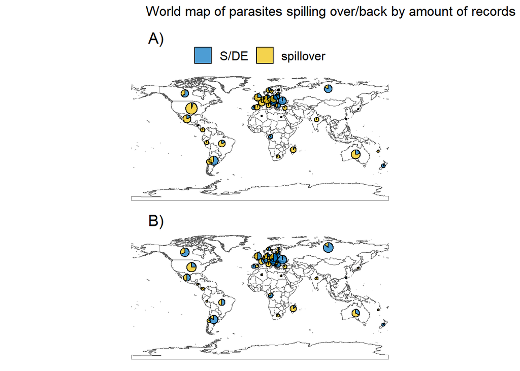

```r
map_records / map_species + plot_annotation(title = "       World map of parasites spilling over/back by amount of records (A) and number of species (B)")
```